# Data 605 HW 15

Cesar Espitia

5/20/2018

### Prob 1

Find the equation of the regression line for the given points. Round any final values to the nearest hundredth, if necessary. ( 5.6, 8.8 ), ( 6.3, 12.4 ), ( 7, 14.8 ), ( 7.7, 18.2 ), ( 8.4, 20.8 )

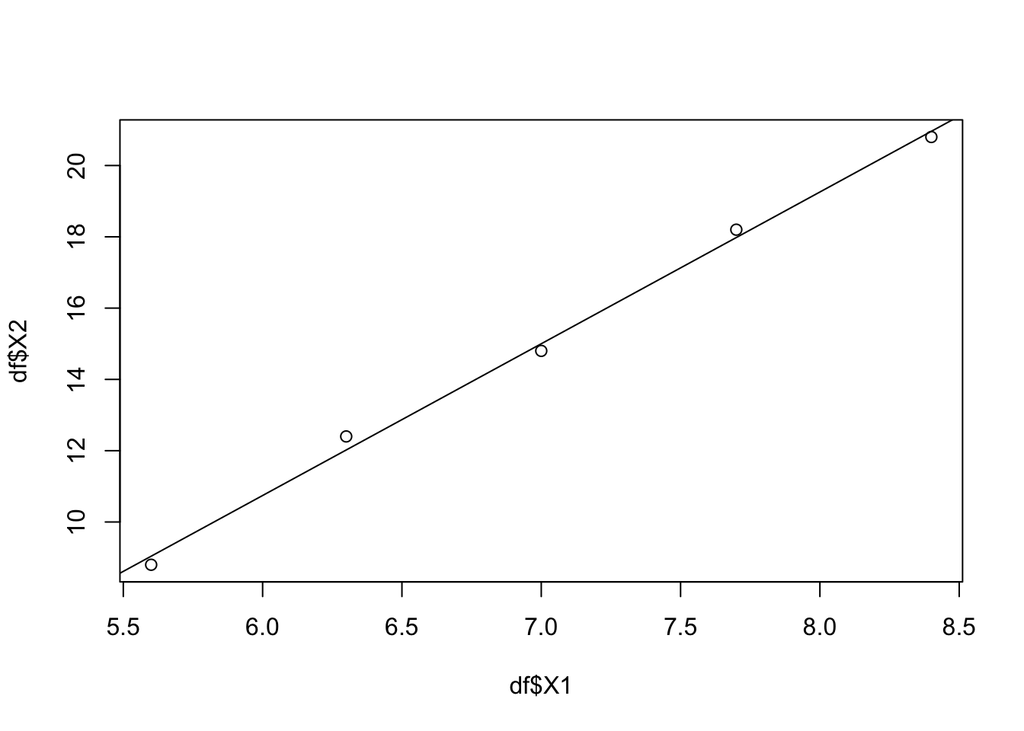

```r
df = data.frame(rbind(c( 5.6, 8.8 ), c( 6.3, 12.4 ), c( 7, 14.8 ), c( 7.7, 18.2 ), c( 8.4, 20.8 )))

model <- lm(df$X2 ~ df$X1, df)

plot(df$X2 ~ df$X1, data=df)
abline(model)
```

### Prob 2

Find all local maxima, local minima, and saddle points for the function given below. $f(x,y) = 24x - 6xy^2 - 8y^3$

Write your answer(s) in the form ( x, y, z ). Separate multiple points with a comma.

Solution: in order to find the answer we need the first and the second partial derivatives.

$df/dx = 24-6y^2$ $df/dy = -12xy-24y^2$

$d^2f/dx = 0$ $d^2f/dy = -12x-48y$

$df/dx = 24-6y^2 = 0 -> 4-y^2=0$ $df/dy = -12xy-24y^2 = 0 -> -xy-2y^2=0$

y=+/-2. when y=2 then x=-4 and when y=-2 then x=4. So our points are (4,-2) and (-4,2).

for (4,-2) $f(x,y) = 24*4-6*4*(-2)^2-8(-2)^3 = 64$ which is > 0

for (-4,2) $f(x,y) = 24*-4-(6*-4*(2)^2)-8(2)^3 = -64$ which is < 0

So only (-4,2) is the saddle point.

### Prob 3

A grocery store sells two brands of a product, the “house” brand and a “name” brand. The manager estimates that if she sells the “house” brand for x dollars and the “name” brand for y dollars, she will be able to sell 81  21x + 17y units of the “house” brand and 40 + 11x  23y units of the “name” brand . Step 1. Find the revenue function R ( x, y ).

House brand: R(x)=x∗(81−21x+17y)

Name brand: R(y)=y∗(40+11x−23y)

Total = $R(x,y)=x∗(81−21x+17y)+y∗(40+11x−23y) -> - 21x^2 - 23y^2 + 28xy + 81x + 40y $

Step 2. What is the revenue if she sells the “house” brand for $2.30 and the “name” brand for $4.10?

```r
x = 2.3
y = 4.1
total <- -21*x^2 - 23*y^2 + 28*x*y + 81*x + 40*y

print(total)
```

```
## [1] 116.62
```

we get $116.62 if they sell at $2.3 and $4.1

### Prob 4

A company has a plant in Los Angeles and a plant in Denver. The firm is committed to produce a total of 96 units of a product each week. The total weekly cost is given by $C(x, y) = (1/6)*x2 + (1/6)*y2 + 7*x + 25*y + 700$, where x is the number of units produced in Los Angeles and y is the number of units produced in Denver. How many units should be produced in each plant to minimize the total weekly cost?

$x+y=96$ so we substitute $y=96-x$

reducing the C(x,y) gives us $x^2-50*x+4636$

Solving the first derivative gives us $x=75$ which means that y=21. LA must produce 75 units and Denver 21 to reduce the total weekly costs.

### Prob 5

Write your answer in exact form without decimals.

$e^(8x+3y) = e^(8*x)+e^(3*y)$

evaluating each section individually you get

$(e^12-e^6)(e^32-e^16)/24$